# silver_final_project_analysis

```r
#for analyses and visualizations
library(tidyverse)
```

```r
library(ggimage)
library(png)
library(knitr)

#for textual analysis / wordcloud / sentiment
library(wordcloud)
library(tm)
library(SnowballC)
library(syuzhet)
```

## Pulling in data

Now that I have my Reddit data secured, I can begin constructing analyses with it.

```r
df_reddit <- read.csv("./data/reddit_top100_posts.csv")
```

I’m going to make a new dataframe tallying the total Reddit score for each player:

```r
df_rank <- df_reddit %>%
  group_by(player_name) %>%
  summarize(total_score = sum(data.score)) %>%
  arrange(desc(total_score))
```

And now I can rank them according to that total score.

```r
df_rank <- df_rank %>%
  mutate(reddit_rank = row_number())
```

This gives me a comparison point for the Ringer rankings, which I’ll pull in now:

```r
df_ringer <- read.csv("./data/nba_ringer_top100_TIDY.csv")
```

Because I already have the field “player_rank” in my Ringer data, I can now bring that in as a variable in my overall ranking dataframe. I just need to conduct a merge using the player_names, which are identical across dataframes:

```r
df_ringer <- df_ringer %>%
  rename(ringer_rank = player_rank)

df_ringer_merge <- df_ringer %>%
  select(c(player_name, ringer_rank))

df_rank <- merge(df_rank, df_ringer_merge, by = "player_name")
```

For an initial visualization, let’s compare reddit_rank to ringer_rank, to see if, generally speaking, players considered better by the ringer are also more popular discussion topics in the r/nba community:

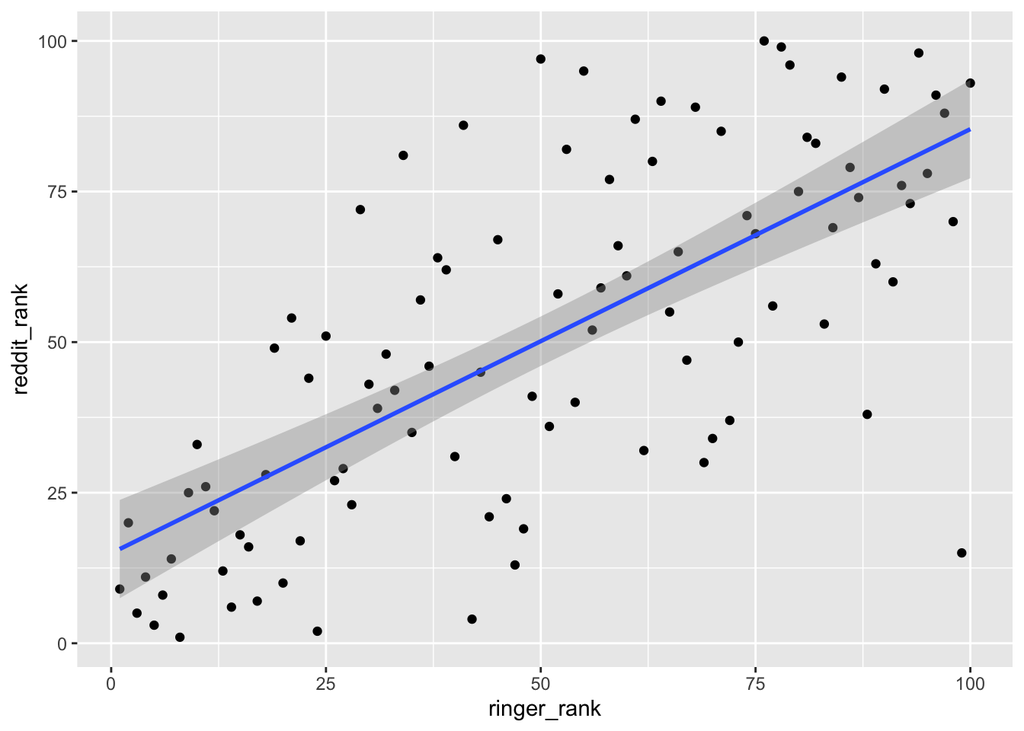

```r
df_rank %>%
  ggplot(aes(x = ringer_rank,
             y = reddit_rank)) +
  geom_point() +
  geom_smooth(method = "lm")
```

While this is useful for overall understanding, it’s easy to forget that each dot on this plot represents a player. For continued analysis, it would be useful (and, let’s face it, fun) to see pictures of each player represented on the plot. This is possible with a package called **ggimage**.

```r
df_pic_files <- read.csv("data/nba_ringer_top100_pic_files.csv")
```

```r
df_rank_pics <- merge(df_rank, df_pic_files, by = "player_name")
```

[figure not shown]

```r
df_rank_pics %>%
  ggplot(aes(x = ringer_rank,
             y = reddit_rank,
             image = picture_file_path)) +
  geom_point() +
  geom_smooth(method = "lm") +
  geom_image(size = 0.05)
```

Awesome! Now let’s see the results of this model:

```r
model <- lm(reddit_rank ~ ringer_rank, data = df_rank)
model_summary <- summary(model)

model_summary
```

```
##
## Call:
## lm(formula = reddit_rank ~ ringer_rank, data = df_rank)
##
## Residuals:
##     Min      1Q  Median      3Q     Max
## -69.655 -13.229   0.014  13.070  46.852
##
## Coefficients:
##             Estimate Std. Error t value Pr(>|t|)
## (Intercept) 14.93697    4.17175   3.581 0.000536 ***
## ringer_rank  0.70422    0.07172   9.819 2.99e-16 ***
## ---
## Signif. codes:  0 '***' 0.001 '**' 0.01 '*' 0.05 '.' 0.1 ' ' 1
##
## Residual standard error: 20.7 on 98 degrees of freedom
## Multiple R-squared:  0.4959, Adjusted R-squared:  0.4908
## F-statistic: 96.41 on 1 and 98 DF,  p-value: 2.989e-16
```

The model appears to fit decently well, meaning that, broadly, the “better” players as ranked by the Ringer tend to be discussed and upvoted more on r/nba. However, there are clearly many departures from this pattern hindering the model. These departures are reflected in the residuals produced by the model, which we can insert back into our table and see our biggest outliers:

```r
df_rank <- df_rank %>%
  cbind(residual = residuals(model))
```

```r
df_rank %>%
  arrange(desc(residual))
```

```
##                 player_name total_score reddit_rank ringer_rank    residual
## 82             O.G. Anunoby       22640          97          50  46.8521092
## 62          Khris Middleton       58920          86          41  42.1900750
## 12           Brandon Ingram       64868          81          34  42.1196040
## 87      Robert Williams III       26775          95          55  41.3310171
## 21           Darius Garland       83682          72          29  36.6406961
## 29            Devin Vassell        7166         100          76  31.5424302
## 35             Franz Wagner       39998          90          64  29.9930513
## 49             Jerami Grant       64174          82          53  29.7394539
## 98       Wendell Carter Jr.       13693          99          78  29.1339934
## 6           Anfernee Simons       52833          87          61  29.1057066
## 10         Bojan Bogdanovic       47571          89          68  26.1761776
## 58           Keldon Johnson       22640          96          79  25.4297750
## 84            Pascal Siakam      127763          54          21  24.2744434
## 46            Jarrett Allen      110359          64          38  22.3027303
```

[output cut: 86 more lines]

Sorting this table by residuals is a great, quick way to understand discussion patterns relative to perceived player ability. Players with very low residuals (meaning high-ranking in Reddit discussions despite relatively low Ringer ranking) are perhaps discussed more popularly on Reddit than their skill might suggest. Players with high residuals are thought to be better players, but are perhaps under-discussed in spite of that. While I have some qualitative hunches for why this might be, continued analysis could help shed light on these patterns.

### Wordcloud

For any given player, it would be interesting to see common words coming up in Reddit threads involving them. Here, I define a function to do just that.

```r
make_player_wordcloud <-  function(player_name_wc) {

  player_name_wc <- gsub("[[:punct:]]", "", player_name_wc)
  player_name_split <- strsplit(player_name_wc, " ")[[1]]
  player_name_split_lower <- tolower(player_name_split)
  player_name_split_lower

  #limit text to particular player
  text_col <- df_reddit %>%
    filter(player_name == player_name_wc) %>%
    select(data.title)

  #store text as corpus
  corpus <- Corpus(VectorSource(text_col))

  #cleaning and processing the corpus
  corpus <- tm_map(corpus, content_transformer(tolower))
  corpus <- tm_map(corpus, removePunctuation)
  corpus <- tm_map(corpus, removeNumbers)
  corpus <- tm_map(corpus, removeWords, stopwords("english"))
  corpus <- tm_map(corpus, stripWhitespace)

  #creating term matrix
  dtm <- TermDocumentMatrix(corpus)

  # Convert the matrix to a dataframe
  m <- as.matrix(dtm)
  v <- sort(rowSums(m),decreasing=TRUE)

  # Create a data frame with words and their frequencies
  d <- data.frame(word = names(v),freq=v)

  #remove individual player's names from word list to not crowd out cloud
  d <- d[!(d$word %in% player_name_split_lower),]

  # Generate the wordcloud
  wordcloud(words = d$word, freq = d$freq, min.freq = 2,
            max.words=400, random.order=FALSE, rot.per=0.35,
            colors=brewer.pal(8, "Dark2"))

}
```

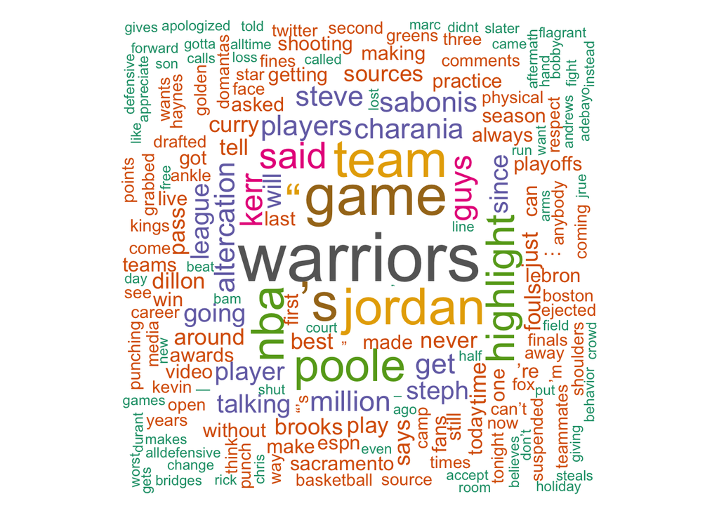

```r
#suppressing warnings because some words can't fit on the page
suppressWarnings(make_player_wordcloud("Draymond Green"))
```

```r
df_reddit %>%
  filter(player_name == "Draymond Green") %>%
  head() %>%
  select(c("data.title", "data.score"))
```

```
##                                                                                                                                                                                                                                                                                            data.title
## 1                                                                                                                                                                                                                                             Video of Draymond Green violently punching Jordan Poole
## 2                                                                                                                                                                                                                                                [Highlight] Draymond Green stomps on Sabonis's chest
## 3                                                                                                                                                                                                                                            [Charania] Draymond Green has been suspended for Game 3.
## 4 Draymond Green on Lebron: "I recently said he’s the greatest face the NBA has ever had. Think about the day and age we live in – cameras, social media – he’s never had a scandal. Never been arrested. Never photo’d drunk. Those things go hand in hand with durability, longevity, consistency."
## 5                    I love the energy Boston fans bring to the game," #NBA Commissioner Adam Silver says in response to the Garden crowd screaming F-- You Draymond [Green]. “I want fans to enjoy themselves, of course from the league office you want to see it done with respect, but I get it."
## 6                                                                                                                                                                                                                            How Draymond Green Was after hitting Jordan Poole in practice [RDC Skit]
##   data.score
## 1      51782
## 2      36140
## 3      32325
## 4      22424
## 5      21020
## 6      15360
```

### Sentiment Analysis

It seems that one of the things that might help shed light on why certain player’s are “over-discussed” is whether they are associated with negative news stories. Therefore, some light sentiment analysis might be useful in understanding potential correlation here.

```r
df_reddit$post_title_sentiment <- get_sentiment(df_reddit$data.title)
```

Here, I’ll make a new dataframe to track the average post sentiment for each player.

```r
df_reddit_sentiment <- df_reddit %>%
  group_by(player_name) %>%
  summarize(avg_sentiment = mean(post_title_sentiment))
```

Now, I’ll add this average sentiment score to df_rank, to facilitate more correlation work.

```r
df_rank <- merge(df_rank, df_reddit_sentiment, by = 'player_name')
```

Finally, I can correlate residuals with average sentiment to see if text sentiment can help predict whether a player may be over- or under-discussed.

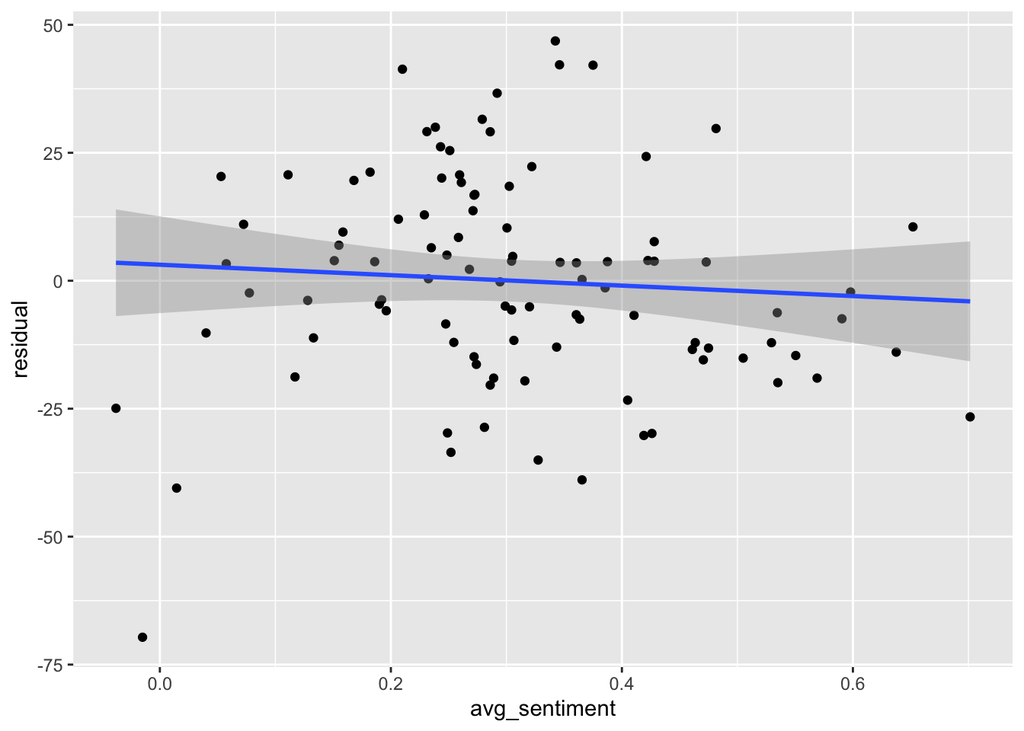

```r
df_rank %>%
  ggplot(aes(x = avg_sentiment,
             y = residual)) +
  geom_point() +
  geom_smooth(method = "lm")
```

Sentiment–or at least, this particular measure of it, is clearly not a strong predictor of residuals in this case. More qualitative analysis may have to suffice for now.